# Week 8 / Exploratory Data Analysis, numeric summary, Lab 05

AG Schissler

Wednesday October 16, 2019

## I. Opening

### I. Start-of-class work

1. Log in the your workstation.
2. Open the RStudio application on your machine.
3. Open 14_eda_numeric_startLab05.Rmd from website so that you can work along the lecture.
4. Open lab_05_numeric_explore_apply.Rmd to have the lab available.

### This week’s agenda

- Continue *Working with data* Unit II.
- Focus on using R to perform numeric exploratory data analysis (EDA).
- More work with the `apply` family of functions.

### Today learning outcomes

Students will be able to

- more practice on reading in (import) data into R
- use `apply` to numerically summarize real data in lab 05

## II. An outlier generating example through a discrete mixture

Let’s discuss how to simulate data with outliers. One way this could arise is that the data in one variable are actually from two distributions that are *mixed* together.

In the code below we simulate $n=1000$ data points from a discrete mixture of Gaussian random variables. Formally, let

$$X \sim N(0,1)$$

and

$$Y \sim N(5,1)$$

be the random variable that results from the (two-component) discrete mixing of $X$ and $Y$ with mixing proportion $\pi \sim bernoulli(p = 0.01)$. By the values we’ve used above the data will appear to have outliers — a few points from away from the majority of points.

```r
## let's simulate and visualize data with outlying points
set.seed(10162109)
## mixing probability
my_pi <- 0.01
## suppose with have 1000 data points
n = 1000
## let's sample which points will be from X and Y
my_index <- rbinom(n = n, size = 1, prob = my_pi)
## count the "outliers"
paste("There are", sum(my_index), "outliers.")
```

```
## [1] "There are 6 outliers."
```

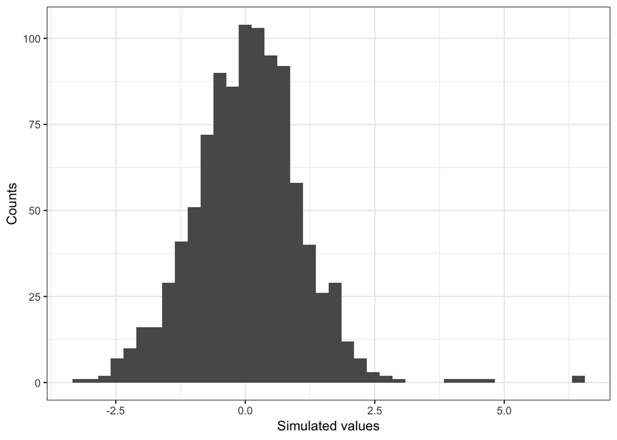

Figure 1. Histogram of 1000 simulated points from a discrete mixture of Gaussians. This produces a few outliers with larger values than the majority of points.

```r
## simulate the values by an "on-the-fly"
## function definition in sapply
## development parameter: tmp_index <- 0
my_sim_data <- sapply(X = my_index, FUN = function(tmp_index){
    ## ifelse works since 1 == TRUE and 0 == FALSE
    ifelse(test = tmp_index, yes = rnorm(1, 5, 1), no = rnorm(1,0,1))
})
ggplot2::qplot(x = my_sim_data, bins = 40) + ggplot2::theme_bw() + ggplot2::labs(x="Simulated values", y = "Counts")
```

Another common visualization is a (modified) boxplot. Outliers are defined by the $1.5 \times IQR$ rule:

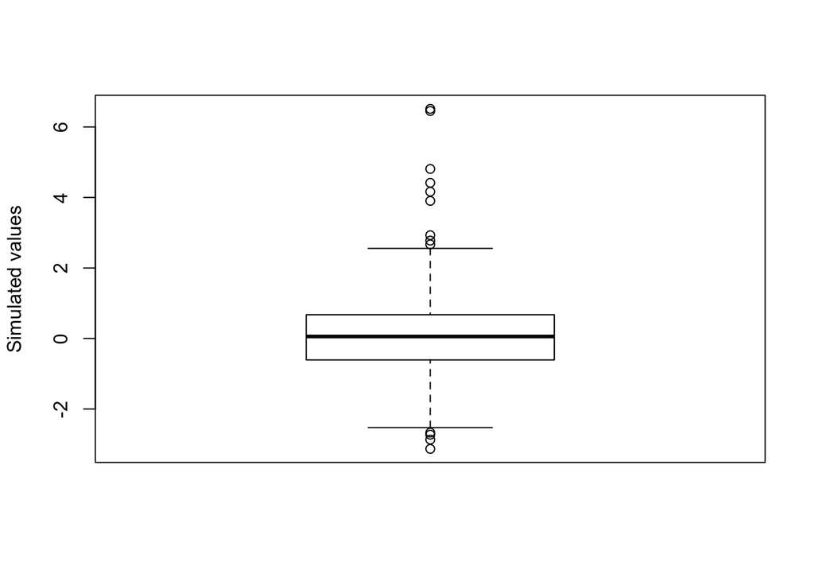

Figure 2. Boxplot of 1000 simulated points from a discrete mixture of Gaussians. Interestingly, the traditional outlier rule in this setting shows outlying points in both directions.

```r
vals <- boxplot(x = my_sim_data, ylab = "Simulated values")
```

```r
vals$out
```

```
##  [1]  6.512562  4.415143  2.668369  3.902983 -2.729200  6.453118 -2.670424
##  [8] -2.868340  4.809299  4.163974  2.776936  2.929626 -3.131138
```

### The point for EDA is that outliers will sometimes be identified by methods and the analyst much hypothesize the generating mechanism.

- Questions for the whole group? Please don’t be shy it could save us all effort.
- Please begin and I will answer questions in the order I receive them and considering who I have helped previously in class.

## IV. Summary

Why do we perform EDA before fitting any statistical model?